**This tutorial will give a short introduction in linkage mapping and QTL mapping. The tutorial is inspired by the many great r/QTL tutorials available at https://rqtl.org/tutorials/ and developped specifically for this workshop by Thomas Blankers.**

# Section 1 - Data

We will use a data set with genotype and phenotype data for 263 individuals and 170 genetic markers. The individuals are all hybrid male offspring of a cross between the Hawaiian swordtail crickets *Laupala paranigra* and *Laupala kona*. Each individual has been sequenced using Genotype-by-Sequencing and thousands of SNPs were available, but these 170 markers present a subset of high quality, well-spaced SNPs with high coverage. The phenotype column "pr" gives the pulse rate (number of pulses per second) of the male song. In *Laupala paranigra* the average pulse rate is 0.71 +/– 0.08 pulses/s. In *L. kona* the average pulse rate is 2.17 +/– 0.08 pulses/s. We will now first read in and inspect the data. Markers that are linked to the X chromosome are categorized as such, as these markers behave differently from the autosomal markers. This is because crickets are XX-XO, meaning males have only one copy of the X and cannot be heterozygote for any X-linked loci. These data were part of a comparative QTL mapping study published here: https://royalsocietypublishing.org/doi/10.1098/rspb.2019.1479

```r
library(qtl)
```

```r
mapfile<-read.cross(file="Parkon_Initial_MapFile_unordered.csv", format="csv", sep=";")
```

```
 --Read the following data:
	 263  individuals
	 169  markers
	 3  phenotypes
 --Cross type: f2
```

Notice that it says: "cross type f2". *What is in that case the expected ratio of AA, BB, and AB genotypes?*

```r
summary(mapfile)
```

```
    F2 intercross

    No. individuals:    263

    No. phenotypes:     3
    Percent phenotyped: 100 96.2 100

    No. chromosomes:    2
        Autosomes:      1
        X chr:          X

    Total markers:      169
    No. markers:        150 19
    Percent genotyped:  98.7
    Genotypes (%):
          Autosomes:        AA:24.5      AB:48.8      BB:26.7  not BB:0.0
                        not AA:0.0
       X chromosome:        AY:49.4      BY:50.6
```

*Do the observed and expected ratio of AA, AB, and BB genotypes match? What would have been the expected ratio of AA:AB:BB in case of a backcross?*

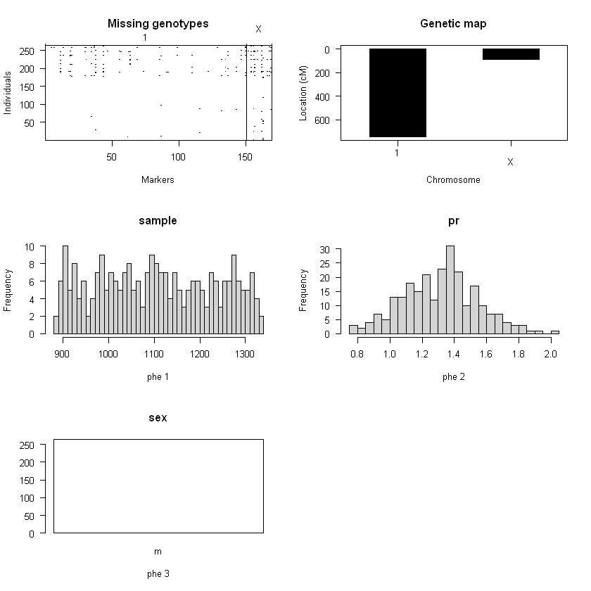

```r
plot(mapfile)
```

Notice that some individuals are missing more genotype data than others. We can omit individuals that miss more than 1/3 of the genotypes in the mapping.

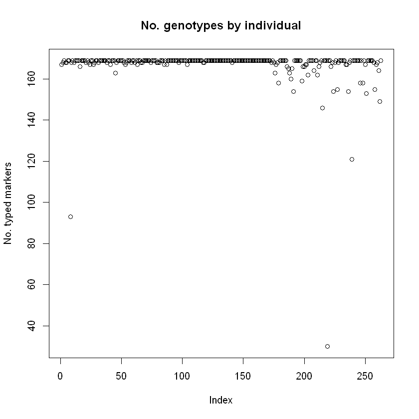

```r
plot(ntyped(mapfile), ylab="No. typed markers", main="No. genotypes by individual")
```

```r
mapfile <- subset(mapfile, ind=(ntyped(mapfile)>113))
```

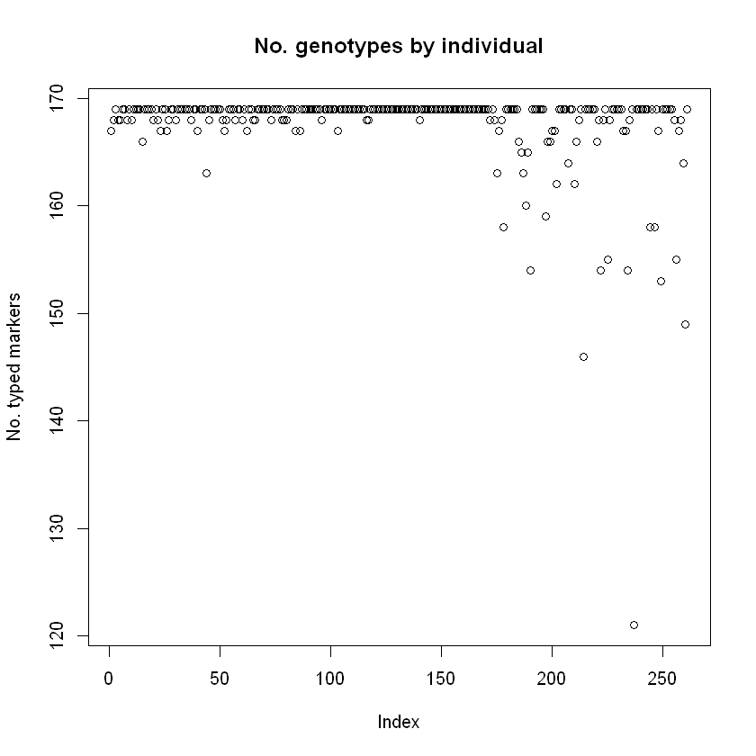

```r
plot(ntyped(mapfile), ylab="No. typed markers", main="No. genotypes by individual")
```

Sometimes genetic markers behave badly. One of the most frequently occuring problems is segregation distortion. Segregation distortion can result from (partial) lethality of an allele from one of the parents in the background of the other parent's genome or from other forms of genetic incompatibility. It may also result from sequencing errors. In general, we expect some variation around the expected genotype ratios due to sampling variance, but we usually filter out markers that deviate strongly from expected ratios.

```r
gt <- geno.table(mapfile)
```

```r
gt[gt$P.value < 0.05,]
```

A data.frame: 20 × 10

|  | chr <fct> | missing <dbl> | AA <dbl> | AB <dbl> | BB <dbl> | not.BB <dbl> | not.AA <dbl> | AY <dbl> | BY <dbl> | P.value <dbl> |
| --- | --- | --- | --- | --- | --- | --- | --- | --- | --- | --- |
| S002002_1983494 | 1 | 16 | 71 | 103 | 71 | 0 | 0 | 0 | 0 | 0.044865703 |
| S003923_717053 | 1 | 8 | 70 | 105 | 78 | 0 | 0 | 0 | 0 | 0.020098409 |
| S001416_360557 | 1 | 9 | 67 | 105 | 80 | 0 | 0 | 0 | 0 | 0.015442452 |
| S001589_250512 | 1 | 1 | 54 | 150 | 56 | 0 | 0 | 0 | 0 | 0.045397071 |
| S000518_713027 | 1 | 1 | 84 | 109 | 67 | 0 | 0 | 0 | 0 | 0.011066352 |
| S000944_580252 | 1 | 0 | 50 | 152 | 59 | 0 | 0 | 0 | 0 | 0.021226807 |
| S000872_603338 | 1 | 1 | 41 | 142 | 77 | 0 | 0 | 0 | 0 | 0.002260187 |
| S001602_107518 | 1 | 0 | 43 | 142 | 76 | 0 | 0 | 0 | 0 | 0.005595326 |
| S004998_209984 | 1 | 0 | 85 | 113 | 63 | 0 | 0 | 0 | 0 | 0.014978350 |
| S000309_37164 | 1 | 0 | 78 | 110 | 73 | 0 | 0 | 0 | 0 | 0.036294395 |
| S005469_84854 | 1 | 4 | 82 | 105 | 70 | 0 | 0 | 0 | 0 | 0.007766182 |
| S000430_73213 | 1 | 0 | 53 | 126 | 82 | 0 | 0 | 0 | 0 | 0.034136276 |
| S001096_197242 | 1 | 2 | 58 | 114 | 87 | 0 | 0 | 0 | 0 | 0.006082639 |
| S006764_43351 | 1 | 7 | 68 | 107 | 79 | 0 | 0 | 0 | 0 | 0.026622881 |
| S004358_50693 | 1 | 6 | 65 | 109 | 81 | 0 | 0 | 0 | 0 | 0.025016109 |
| S001761_660719 | 1 | 7 | 57 | 114 | 83 | 0 | 0 | 0 | 0 | 0.018460426 |
| S002190_206294 | 1 | 1 | 58 | 119 | 83 | 0 | 0 | 0 | 0 | 0.035628287 |
| S001904_134885 | 1 | 8 | 63 | 110 | 80 | 0 | 0 | 0 | 0 | 0.037087830 |
| S001507_47540 | 1 | 1 | 51 | 126 | 83 | 0 | 0 | 0 | 0 | 0.017222503 |
| S000219_813147 | X | 17 | 0 | 0 | 0 | 0 | 0 | 139 | 105 | 0.029508412 |

```r
gt[gt$P.value < 0.05/totmar(mapfile),]
```

A data.frame: 0 × 10

| chr | missing | AA | AB | BB | not.BB | not.AA | AY | BY | P.value |
| --- | --- | --- | --- | --- | --- | --- | --- | --- | --- |
| <fct> | <dbl> | <dbl> | <dbl> | <dbl> | <dbl> | <dbl> | <dbl> | <dbl> | <dbl> |

Some markers show low levels of segregation distortion, but after Bonferroni correction, none of the Chi-square p-values are below the 0.05 threshold.

# Section 2 - Linkage Mapping

Two parameters control the grouping of the markers into linkage groups. max.rf: Maximum recombination fraction for placing two markers in the same linkage group. The higher you set this fraction, the more loosely linked you allow markers to be for them to still be considered on the same linkage group. min.lod: Minimum LOD score for placing two markers in the same linkage group. The higher you set this score, the more strongly linked you expect markers to be for them to be considered on the same linkage group. If one of the two criteria is more stringent about linkage than the other, this will be the criterium that determines the grouping. (So the criteria are only partially complementary and may act redundantly). We expect there to be 7 autosomes in addition to the X chromosome. Play with max.rf and min.lod values in the code below until the number of linkage groups corresponds to the expected number of chromosomes. In the table below, the top row gives the linkage group(s) and the bottom row the number of markers per linkage group. *If you cannot get the exact number of expected chromosomes, would it be better to have more or fewer linkage groups than the expected number of chromosomes?*

```r
max.rf=0.5
min.lod=1
lg <- formLinkageGroups(mapfile, max.rf=max.rf, min.lod=min.lod)
table(lg[,2])
```

```
  1
169
```

```r
max.rf=0.25
min.lod=4
lg <- formLinkageGroups(mapfile, max.rf=max.rf, min.lod=min.lod)
table(lg[,2])
```

```
 1  2  3  4  5  6  7  8
26 25 25 23 19 19 16 16
```

```r
mapfile <- formLinkageGroups(mapfile, max.rf=max.rf, min.lod=min.lod, reorgMarkers=TRUE)
```

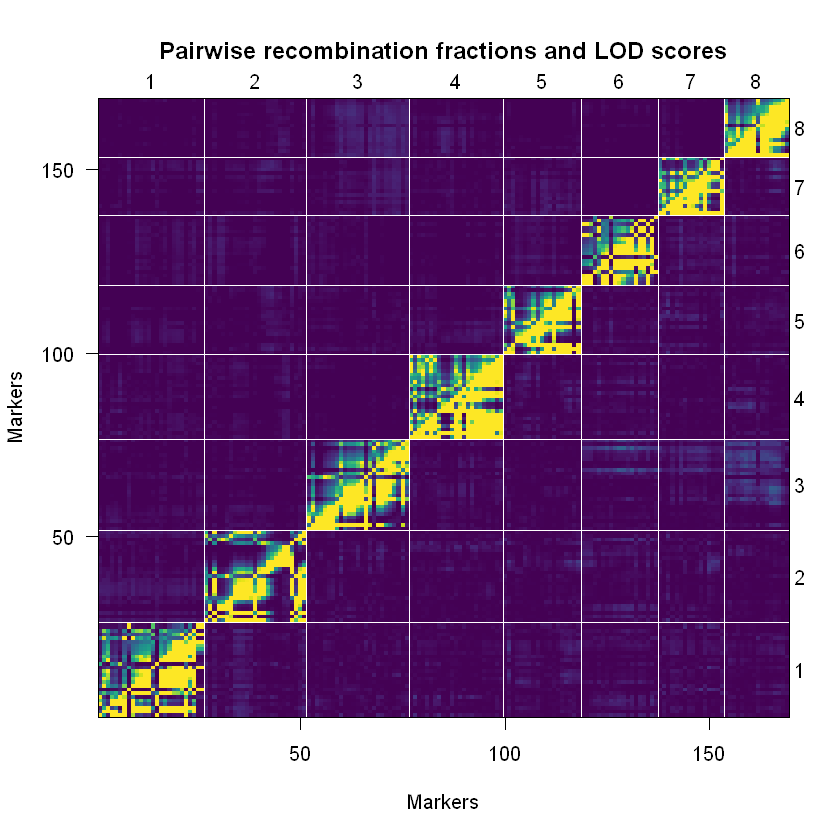

```r
plotRF(mapfile)
```

The figure above shows the linkage among markers, with blue hues indicating weak linkage and yellow hues indicating strong linkage. What you can see now is that markers are associated with each other stronger within compared to among linkage groups, which is as expected. But we can also see that markers are not sorted well within linkage groups, as you would expect neighboring markers to be more closely associated than markers on opposite ends of linkage groups. For this we need to order the markers.

```r
mapfile <- orderMarkers(mapfile, chr=7) # order markers on linkage group 7
```

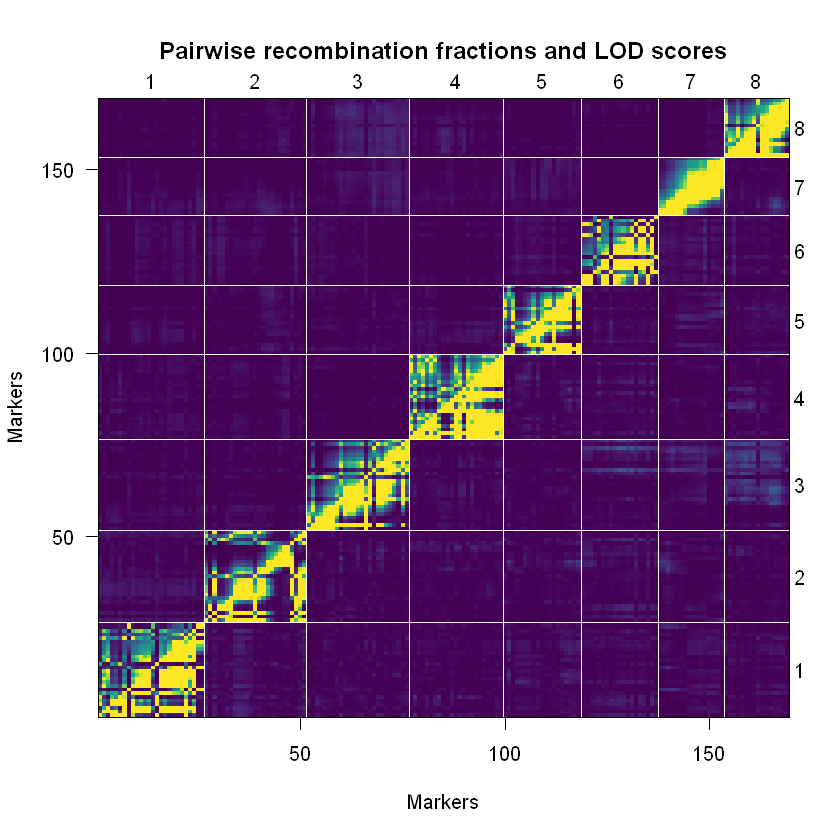

```r
plotRF(mapfile)
```

*What is the difference between the heatmap above and the one before ordering markers on LG7?*

The orderMarkers function is quite fast but not always very accurate. We can inspect alternative orders using the ripple function, which basically permutes orders within windows of a given size. You can change the method to only look at expected cross-over count or use a likelihood framework (latter is more computationally intensive) and you can vary the window size (the number of markers for which the order is varied per step). It is best to avoid large windows (> 5 for the likelihood method, > 9 for the cross-over count based method) depending on computational resources.

```r
rip7 <- ripple(mapfile, chr=7, window=4, method="likelihood")
```

```
   240 total orders
    --Order 10
    --Order 20
    --Order 30
    --Order 40
    --Order 50
    --Order 60
    --Order 70
    --Order 80
    --Order 90
    --Order 100
    --Order 110
    --Order 120
    --Order 130
    --Order 140
    --Order 150
    --Order 160
    --Order 170
    --Order 180
    --Order 190
    --Order 200
    --Order 210
    --Order 220
    --Order 230
    --Order 240
```

```r
summary(rip7)
```

A summary.ripple: 2 × 18 of type dbl

|  |  |  |  |  |  |  |  |  |  |  |  |  |  |  |  |  | LOD | chrlen |
| --- | --- | --- | --- | --- | --- | --- | --- | --- | --- | --- | --- | --- | --- | --- | --- | --- | --- | --- |
| Initial | 1 | 2 | 3 | 4 | 5 | 6 | 7 | 8 | 9 | 10 | 11 | 12 | 13 | 14 | 15 | 16 | 0.000000 | 88.46422 |
| 1 | 2 | 1 | 3 | 4 | 5 | 6 | 7 | 8 | 9 | 10 | 11 | 12 | 13 | 14 | 15 | 16 | -2.796872 | 89.58280 |

We see there is no alternative order that has a higher likelihood and/or shorter linkage group length.

With this we have covered the basics of linkage mapping. Linkage mapping is a bit of an art and usually requires many tries of orders and using different sources of information that can help define which orders are better than others. In my personal experience, MapMaker and Joinmap perform a bit better than rQTL, but this will highly depend on the data that you have and it is worthwile investing in exploring different software packages. For this tutorial we will stop here. We will now continue with QTL mapping.

# Section 3 - QTL mapping

We will read in new data that have all the linkage groups ordered neatly.

```r
qtl<-read.cross(file="Parkon_Initial_CrossFile.csv", format="csv", sep=";")
```

```
 --Read the following data:
	 263  individuals
	 170  markers
	 3  phenotypes
```

```
 --Cross type: f2
```

```r
summary(qtl)
```

```
    F2 intercross

    No. individuals:    263

    No. phenotypes:     3
    Percent phenotyped: 100 96.2 100

    No. chromosomes:    8
        Autosomes:      1 2 3 4 5 6 7
        X chr:          X

    Total markers:      170
    No. markers:        26 25 25 20 16 16 23 19
    Percent genotyped:  98.7
    Genotypes (%):
          Autosomes:        AA:24.5      AB:48.9      BB:26.7  not BB:0.0
                        not AA:0.0
       X chromosome:        AY:49.4      BY:50.6
```

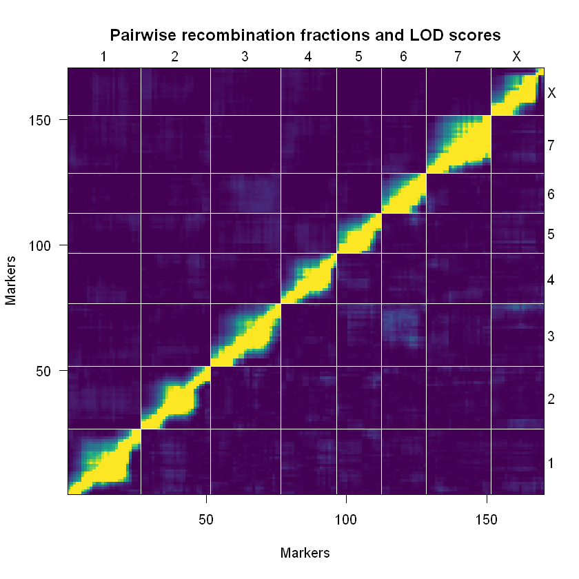

```r
plotRF(qtl)
```

```r
qtl<-jittermap(qtl) # jitter markers that are at the exact same location
```

### 3.1 Single QTL mapping

r/QTL uses a Hidden Markov Model to take the information from the observed genotypes and calculate genotype probabilities or simulate genotypes, depending on the QTL algorithm that is used. We can incorporate information about genotyping/sequencing errors and set the resolution at which genotypes probabilities are calculated or at which genotypes are simulated. This resolution trades-off with computational requirements, of course. The simplest approach to QTL mapping in r/QTL is the scanone function. This function scans each linkage group for associations between marker genotypes and phenotypes. We first run scanone using the Haley-Knott regression, for which genotype probabilities need to be calculated.

```r
qtl <- calc.genoprob(qtl, step=1, error.prob=0.01) # step sets the resolution in cM and error.prob is the genotyping error
```

```r
qtl_one_hk <- scanone(qtl, method="hk", pheno.col="pr")
```

```r
summary(qtl_one_hk)
```

A summary.scanone: 8 × 3

|  | chr <fct> | pos <dbl> | lod <dbl> |
| --- | --- | --- | --- |
| c1.loc59 | 1 | 59.000000 | 4.7261579 |
| c2.loc55 | 2 | 55.000000 | 10.3459768 |
| c3.loc107 | 3 | 107.000000 | 2.5534887 |
| c4.loc51 | 4 | 51.000000 | 8.7452605 |
| c5.loc34 | 5 | 34.000000 | 40.3995854 |
| S003103_1046679 | 6 | 8.100001 | 0.6021456 |
| c7.loc9 | 7 | 9.000000 | 1.0881428 |
| cX.loc67 | X | 67.000000 | 2.7691975 |

This table shows the marker on each linkage group with the highest LOD score for the association between genotype and phenotype. In order to know which of these peaks reach beyond genome-wide significance levels, we use permutation.

```r
qtl_one_hk_1000perm <- scanone(qtl, method="hk", pheno.col="pr", n.perm=1000, perm.Xsp=TRUE)
```

```
--Autosome permutations
Doing permutation in batch mode ...
--X chromosome permutations
Doing permutation in batch mode ...
```

```r
summary(qtl_one_hk_1000perm, alpha=c(0.05,0.01))
```

```
Autosome LOD thresholds (1000 permutations)
    lod
5% 3.34
1% 4.18

X chromosome LOD thresholds (7967 permutations)
    lod
5% 2.68
1% 3.49
```

*So, which chromosomes harbour a QTL?*

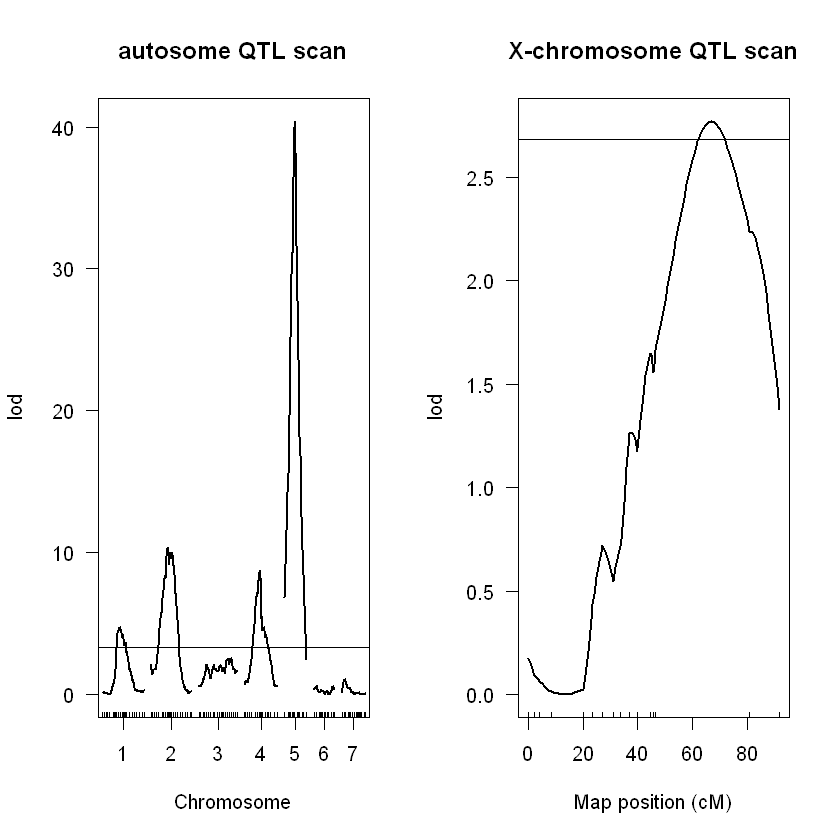

```r
par(mfrow=c(1,2))
plot(qtl_one_hk, chr=seq(1:7), main="autosome QTL scan")
abline(h=summary(qtl_one_hk_1000perm, alpha=c(0.05))[1])
plot(qtl_one_hk, chr="X", main="X-chromosome QTL scan")
abline(h=summary(qtl_one_hk_1000perm, alpha=c(0.05))[2])
```

An alternative algorithm is "multiple imputation". This method may be more accurate in some instances, but it is much more computationally intensive.

```r
qtl <- sim.geno(qtl, step=1, error.prob=0.01)
qtl_one_imp <- scanone(qtl, method="imp", pheno.col="pr")
```

```r
qtl_one_imp_1000perm <- scanone(qtl, method="imp", pheno.col="pr", n.perm=1000, perm.Xsp=TRUE)
```

```
--Autosome permutations
Doing permutation in batch mode ...
--X chromosome permutations
Doing permutation in batch mode ...
```

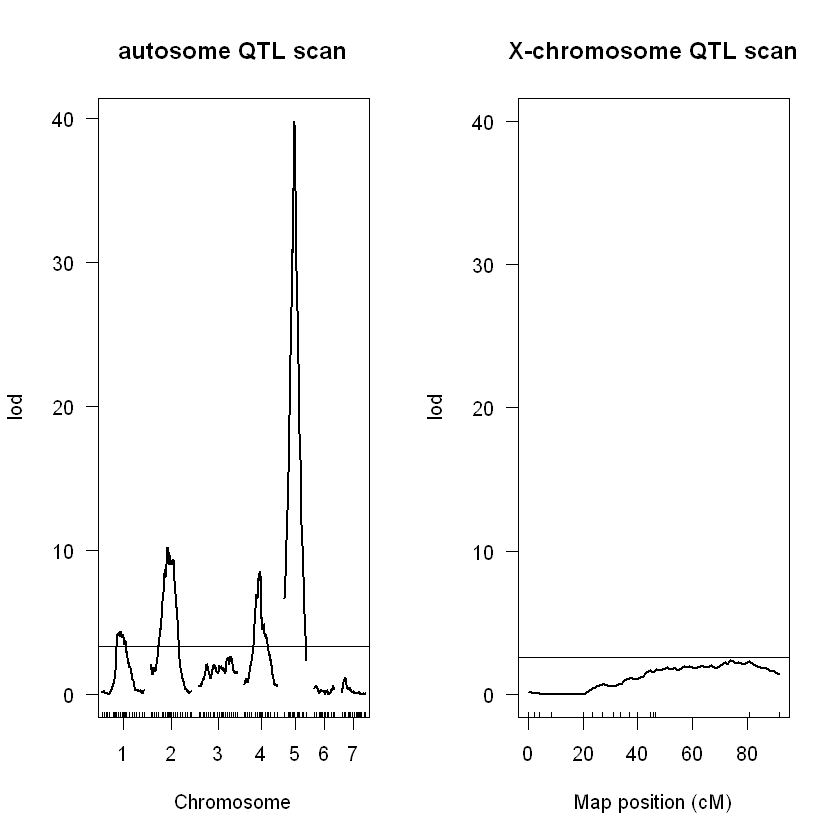

```r
par(mfrow=c(1,2))
plot(qtl_one_imp, chr=seq(1:7), main="autosome QTL scan")
abline(h=summary(qtl_one_imp_1000perm, alpha=c(0.05))[1])
plot(qtl_one_imp, chr="X", ylim=c(0,40), main="X-chromosome QTL scan")
abline(h=summary(qtl_one_imp_1000perm, alpha=c(0.05))[2])
```

*Can you think of a reason why the QTL on the X chromosome is above the permutation threshold when using Haley-Knott regression and below the threshold when using multiple imputation?*

Finding QTL peaks is step one, but a major interest is often in knowing the effect sizes of the identified QTL.

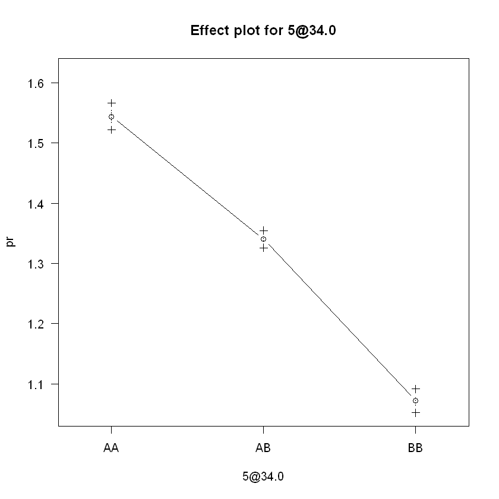

```r
effectplot(qtl,"5@34.0",pheno.col="pr")
```

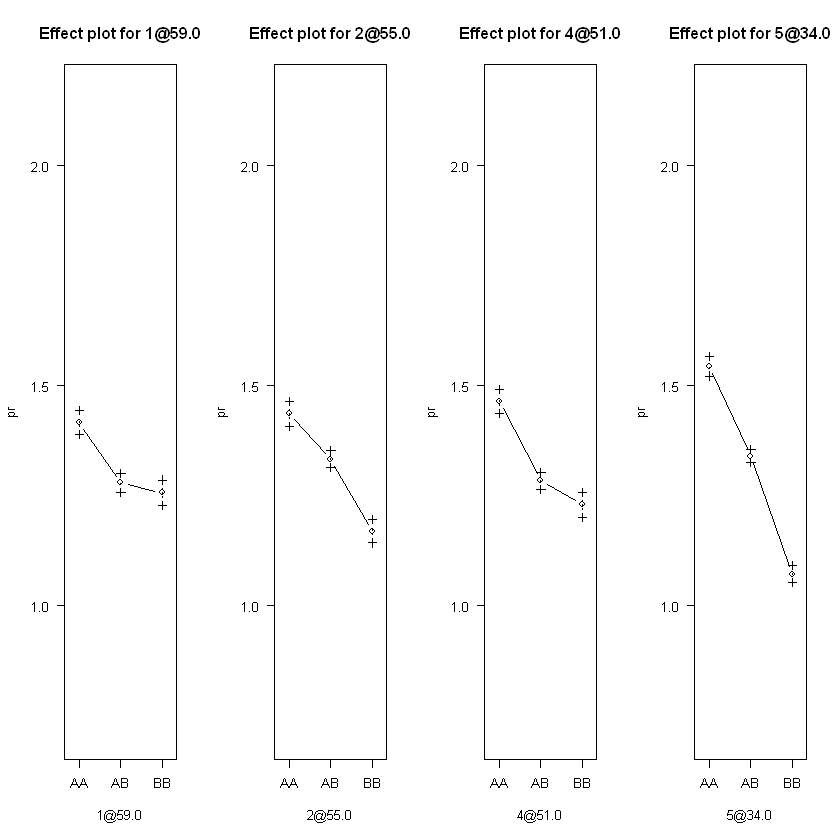

```r
par(mfrow=c(1,4))
effectplot(qtl,"1@59.0",pheno.col="pr", ylim=c(0.71,2.17)) # set y-axis limits to the parental means
effectplot(qtl,"2@55.0",pheno.col="pr", ylim=c(0.71,2.17))
effectplot(qtl,"4@51.0",pheno.col="pr", ylim=c(0.71,2.17))
effectplot(qtl,"5@34.0",pheno.col="pr", ylim=c(0.71,2.17))
```

These plots are very insightful. *What can you tell about these QTL with respect to (i) dominance/additivity, (ii) direction of allelic effects, (iii) magnitude of allelic effects?*

Scanone is easy to apply and fast. However, it fails to take into acount the effects of a QTL on a given linkage group when calculating LOD scores for a second QTL on the same or other linkage groups. For this we need to resort to multiple QTL mapping.

### 3.2 Multiple QTL mapping

We will first run permutations of the scantwo function. The scantwo function itself is useful in determining interactions among QTL across chromosomes as well is in finding secondary QTL within a single chromosome. However, it is quite complicated and beyond the scope of this introduction (The r/QTL tutorials at https://rqtl.org/tutorials/ are very helpful for this and further information).So for now, we will just run the permutations of scantwo and use the thresholds for the multiple QTL mapping.

```r
qtl_two_hk_10perm<-scantwo(qtl, pheno.col="pr", method="hk", clean.output=TRUE, chr=seq(1:7), n.perm=10, perm.Xsp=FALSE)
```

```
Doing permutation in batch mode ...
```

This function is very computationally intensive, so in this example I have set only 10 permutations and only permutations specific to the autosomes. In this case, the penalties calculated below do not deviate much from an analysis for which I did 1000 permuations, so they are fine to use in this tutorial.

```r
penalties=calc.penalties(qtl_two_hk_10perm, alpha=0.05)
```

```r
penalties
```

**main**

2.59954855539306

**heavy**

5.62913793450125

**light**

4.27973737589711

The penalties indicate the minimum required increase in LOD of the new QTL model for adding a QTL to the existing model. So if you have a model with one QTL and would like to add a second QTL, the increase of the LOD of the model has to exceed the threshold value "main". For adding interactions among QTL (epistasis) the increase has to exceed the threshold value "heavy" (stringent threshold) or "light" (relaxed threshold). Now let's build the QTL model.

```r
summary(qtl_one_imp)
```

A summary.scanone: 8 × 3

|  | chr <fct> | pos <dbl> | lod <dbl> |
| --- | --- | --- | --- |
| S002934_86739 | 1 | 63.00001 | 4.3936612 |
| c2.loc54 | 2 | 54.00000 | 10.2166548 |
| c3.loc106 | 3 | 106.00000 | 2.6154286 |
| S000730_618249 | 4 | 52.50001 | 8.5715809 |
| S004683_48328 | 5 | 32.60001 | 39.7946993 |
| S008057_58899 | 6 | 64.20001 | 0.6120757 |
| c7.loc13 | 7 | 13.00000 | 1.1834210 |
| cX.loc74 | X | 74.00000 | 2.4122621 |

```r
qtl_mqm_1_imp<-makeqtl(qtl,chr=5, pos=32.6) # start with the QTL with the highest LOD
summary(fitqtl(qtl, qtl=qtl_mqm_1_imp, dropone=TRUE, get.ests=TRUE, pheno.col="pr", formula = y ~ Q1))
```

```
		fitqtl summary

Method: multiple imputation
Model:  normal phenotype
Number of observations : 253

Full model result
----------------------------------
Model formula: y ~ Q1

       df        SS         MS     LOD     %var Pvalue(Chi2) Pvalue(F)
Model   2  6.984214 3.49210695 39.7947 51.53621            0         0
Error 250  6.567839 0.02627135
Total 252 13.552053


Estimated effects:
-----------------
               est       SE       t
Intercept  1.32309  0.01021 129.598
5@32.6a   -0.23509  0.01460 -16.099
5@32.6d    0.03374  0.02042   1.652
```

The fitqtl table gives information about the QTL model. %var refers to percentage phenotypic variance explained by the full model. It refers to variance in the mapping panel and is usually higher than % variance explained of the parental difference. The estimated effects give, per QTL, the additive and dominance effects of having a B allele (in this case a L. paranigra allele) at that QTL.

```r
qtl_mqm_1_imp_add <- addqtl(qtl, qtl=qtl_mqm_1_imp, pheno.col="pr", method="imp", formula=  y ~ Q1) # scan for additional QTL, accounting for effects of first QTL
```

```r
summary(qtl_mqm_1_imp_add)
```

A summary.scanone: 8 × 3

|  | chr <fct> | pos <dbl> | lod <dbl> |
| --- | --- | --- | --- |
| c1.loc81 | 1 | 81.00000 | 10.6841667 |
| S002151_1134795 | 2 | 54.30001 | 23.0836615 |
| S000304_669102 | 3 | 29.60001 | 3.6416895 |
| S000730_618249 | 4 | 52.50001 | 11.5361805 |
| c5.loc60 | 5 | 60.00000 | 1.8284496 |
| S000628_1124280 | 6 | 23.70001 | 0.7575111 |
| c7.loc13 | 7 | 13.00000 | 0.8621755 |
| cX.loc43 | X | 43.00000 | 3.8342422 |

```r
qtl_mqm_2_imp<-addtoqtl(qtl,qtl_mqm_1_imp, 2, 54.3) # add the next highest QTL
summary(fitqtl(qtl, qtl=qtl_mqm_2_imp, dropone=TRUE, get.ests=TRUE, pheno.col="pr", formula = y ~ Q1 + Q2)) # check model fit to see if LOD increase is higher than main penalty
```

```
		fitqtl summary

Method: multiple imputation
Model:  normal phenotype
Number of observations : 253

Full model result
----------------------------------
Model formula: y ~ Q1 + Q2

       df        SS         MS      LOD     %var Pvalue(Chi2) Pvalue(F)
Model   4  9.237429 2.30935718 62.87836 68.16258            0         0
Error 248  4.314624 0.01739768
Total 252 13.552053


Drop one QTL at a time ANOVA table:
----------------------------------
       df Type III SS   LOD  %var F value Pvalue(Chi2) Pvalue(F)
5@32.6  2       6.951 52.72 51.29  199.76            0    <2e-16 ***
2@54.3  2       2.253 23.08 16.63   64.76            0    <2e-16 ***
---
Signif. codes:  0 '***' 0.001 '**' 0.01 '*' 0.05 '.' 0.1 ' ' 1


Estimated effects:
-----------------
                est        SE       t
Intercept  1.327440  0.008328 159.389
5@32.6a   -0.234585  0.011887 -19.735
5@32.6d    0.030613  0.016653   1.838
2@54.3a   -0.133501  0.011896 -11.222
2@54.3d    0.020366  0.016727   1.218
```

```r
qtl_mqm_2_imp<-refineqtl(qtl, pheno.col="pr", method="imp", qtl = qtl_mqm_2_imp) # refine position of QTL now that information on both QTL is present
summary(fitqtl(qtl, qtl=qtl_mqm_2_imp, dropone=TRUE, get.ests=TRUE, pheno.col="pr", formula = y ~ Q1 + Q2)) # check model fit
```

```
pos: 32.60001 54.30001
Iteration 1
 Q1 pos: 32.60001 -> 32.80001
    LOD increase:  0.302
 Q2 pos: 54.30001 -> 54.30001
    LOD increase:  0
all pos: 32.60001 54.30001 -> 32.80001 54.30001
LOD increase at this iteration:  0.302
Iteration 2
 Q2 pos: 54.30001 -> 54.30001
    LOD increase:  0
 Q1 pos: 32.80001 -> 32.80001
    LOD increase:  0
all pos: 32.80001 54.30001 -> 32.80001 54.30001
LOD increase at this iteration:  0
overall pos: 32.60001 54.30001 -> 32.80001 54.30001
LOD increase overall:  0.302
```

```
		fitqtl summary

Method: multiple imputation
Model:  normal phenotype
Number of observations : 253

Full model result
----------------------------------
Model formula: y ~ Q1 + Q2

       df        SS        MS      LOD     %var Pvalue(Chi2) Pvalue(F)
Model   4  9.261082 2.3152704 63.18036 68.33711            0         0
Error 248  4.290971 0.0173023
Total 252 13.552053


Drop one QTL at a time ANOVA table:
----------------------------------
       df Type III SS   LOD  %var F value Pvalue(Chi2) Pvalue(F)
5@32.8  2       6.974 53.03 51.46  201.54            0    <2e-16 ***
2@54.3  2       2.293 23.52 16.92   66.27            0    <2e-16 ***
---
Signif. codes:  0 '***' 0.001 '**' 0.01 '*' 0.05 '.' 0.1 ' ' 1


Estimated effects:
-----------------
                est        SE       t
Intercept  1.328161  0.008308 159.872
5@32.8a   -0.235840  0.011898 -19.822
5@32.8d    0.029451  0.016606   1.773
2@54.3a   -0.135184  0.011895 -11.365
2@54.3d    0.019092  0.016691   1.144
```

```r
qtl_mqm_2_imp_addint<-addint(qtl, pheno.col="pr",  qtl=qtl_mqm_2_imp, method="imp", formula=  y ~ Q1 + Q2) # check for interactions
```

```r
summary(qtl_mqm_2_imp_addint)
```

A addint: 1 × 7

|  | df <dbl> | Type III SS <dbl> | LOD <dbl> | %var <dbl> | F value <dbl> | Pvalue(Chi2) <dbl> | Pvalue(F) <dbl> |
| --- | --- | --- | --- | --- | --- | --- | --- |
| 5@32.8:2@54.3 | 4 | 0.2465989 | 3.251615 | 1.819642 | 3.719374 | 0.004754939 | 0.005828497 |

```r
summary(fitqtl(qtl, qtl=qtl_mqm_2_imp, dropone=TRUE, get.ests=TRUE, pheno.col="pr", formula = y ~ Q1 + Q2 + Q1:Q2)) # check model fit with interaction added to the model
```

```
		fitqtl summary

Method: multiple imputation
Model:  normal phenotype
Number of observations : 253

Full model result
----------------------------------
Model formula: y ~ Q1 + Q2 + Q1:Q2

       df        SS        MS      LOD     %var Pvalue(Chi2) Pvalue(F)
Model   8  9.507680 1.1884601 66.43198 70.15676            0         0
Error 244  4.044372 0.0165753
Total 252 13.552053


Drop one QTL at a time ANOVA table:
----------------------------------
              df Type III SS    LOD  %var F value Pvalue(Chi2) Pvalue(F)
5@32.8         6      7.2209 56.278 53.28  72.607        0.000   < 2e-16 ***
2@54.3         6      2.5400 26.775 18.74  25.540        0.000   < 2e-16 ***
5@32.8:2@54.3  4      0.2466  3.252  1.82   3.719        0.005   0.00586 **
---
Signif. codes:  0 '***' 0.001 '**' 0.01 '*' 0.05 '.' 0.1 ' ' 1


Estimated effects:
-----------------
                      est        SE       t
Intercept        1.327416  0.008170 162.482
5@32.8a         -0.235380  0.011726 -20.073
5@32.8d          0.027770  0.016299   1.704
2@54.3a         -0.135728  0.011733 -11.568
2@54.3d          0.012504  0.016621   0.752
5@32.8a:2@54.3a  0.002303  0.016494   0.140
5@32.8d:2@54.3a  0.017083  0.023511   0.727
5@32.8a:2@54.3d  0.066950  0.024122   2.775
5@32.8d:2@54.3d  0.094843  0.033006   2.874
```

*Does adding the interaction increases the explanatory power of the model significantly?*

```r
qtl_mqm_2_imp_add <- addqtl(qtl, qtl=qtl_mqm_2_imp, pheno.col="pr", method="imp", formula=  y ~ Q1 + Q2 + Q1:Q2) # scan for additional QTL acounting for the effects of QTL1, QTL2 and their interaction
```

```r
summary(qtl_mqm_2_imp_add)
```

A summary.scanone: 8 × 3

|  | chr <fct> | pos <dbl> | lod <dbl> |
| --- | --- | --- | --- |
| c1.loc78 | 1 | 78.00000 | 9.8119971 |
| c2.loc3 | 2 | 3.00000 | 1.9278859 |
| c3.loc30 | 3 | 30.00000 | 3.5858064 |
| c4.loc53 | 4 | 53.00000 | 19.9574372 |
| S000430_73213 | 5 | 26.60000 | 1.8862492 |
| S000628_1124280 | 6 | 23.70001 | 0.9416415 |
| c7.loc33 | 7 | 33.00000 | 1.1643949 |
| cX.loc57 | X | 57.00000 | 3.6081603 |

```r
qtl_mqm_3_imp<-addtoqtl(qtl,qtl_mqm_2_imp, 4, 53) # add the next highest QTL
summary(fitqtl(qtl, qtl=qtl_mqm_3_imp, dropone=TRUE, get.ests=TRUE, pheno.col="pr", formula = y ~ Q1 + Q2 + Q3+ Q1:Q2)) # check model fit to see if LOD increase is higher than main penalty
```

```
		fitqtl summary

Method: multiple imputation
Model:  normal phenotype
Number of observations : 253

Full model result
----------------------------------
Model formula: y ~ Q1 + Q2 + Q3 + Q1:Q2

       df       SS         MS      LOD     %var Pvalue(Chi2) Pvalue(F)
Model  10 10.73960 1.07396026 86.38941 79.24706            0         0
Error 242  2.81245 0.01162169
Total 252 13.55205


Drop one QTL at a time ANOVA table:
----------------------------------
              df Type III SS   LOD   %var F value Pvalue(Chi2) Pvalue(F)
5@32.8         6      6.4398 65.42 47.519  92.353        0.000   < 2e-16 ***
2@54.3         6      2.5829 35.79 19.059  37.041        0.000   < 2e-16 ***
4@53.0         2      1.2319 19.96  9.090  53.001        0.000   < 2e-16 ***
5@32.8:2@54.3  4      0.1899  3.59  1.401   4.085        0.002   0.00319 **
---
Signif. codes:  0 '***' 0.001 '**' 0.01 '*' 0.05 '.' 0.1 ' ' 1


Estimated effects:
-----------------
                      est        SE       t
Intercept        1.326814  0.006857 193.509
5@32.8a         -0.223151  0.010001 -22.312
5@32.8d          0.043064  0.013948   3.088
2@54.3a         -0.137593  0.009981 -13.785
2@54.3d          0.021457  0.014275   1.503
4@53.0a         -0.096526  0.009933  -9.718
4@53.0d         -0.041361  0.014018  -2.951
5@32.8a:2@54.3a  0.007921  0.014027   0.565
5@32.8d:2@54.3a  0.014876  0.019867   0.749
5@32.8a:2@54.3d  0.039677  0.020560   1.930
5@32.8d:2@54.3d  0.093752  0.027932   3.356
```

```r
qtl_mqm_3_imp<-refineqtl(qtl, pheno.col="pr", method="imp", qtl = qtl_mqm_3_imp) # refine position of QTL now that information on both QTL is present
summary(fitqtl(qtl, qtl=qtl_mqm_3_imp, dropone=TRUE, get.ests=TRUE, pheno.col="pr", formula = y ~ Q1 + Q2 + Q3 + Q1:Q2)) # check model fit
```

```
pos: 32.80001 54.30001 53
Iteration 1
 Q2 pos: 54.30001 -> 54.30001
    LOD increase:  0
 Q1 pos: 32.80001 -> 32.80001
    LOD increase:  0
 Q3 pos: 53 -> 53
    LOD increase:  0
all pos: 32.80001 54.30001 53 -> 32.80001 54.30001 53
LOD increase at this iteration:  0
overall pos: 32.80001 54.30001 53 -> 32.80001 54.30001 53
LOD increase overall:  0
```

```
		fitqtl summary

Method: multiple imputation
Model:  normal phenotype
Number of observations : 253

Full model result
----------------------------------
Model formula: y ~ Q1 + Q2 + Q3 + Q1:Q2

       df       SS         MS      LOD     %var Pvalue(Chi2) Pvalue(F)
Model  10 10.73960 1.07396026 86.38941 79.24706            0         0
Error 242  2.81245 0.01162169
Total 252 13.55205


Drop one QTL at a time ANOVA table:
----------------------------------
              df Type III SS   LOD   %var F value Pvalue(Chi2) Pvalue(F)
5@32.8         6      6.4398 65.42 47.519  92.353        0.000   < 2e-16 ***
2@54.3         6      2.5829 35.79 19.059  37.041        0.000   < 2e-16 ***
4@53.0         2      1.2319 19.96  9.090  53.001        0.000   < 2e-16 ***
5@32.8:2@54.3  4      0.1899  3.59  1.401   4.085        0.002   0.00319 **
---
Signif. codes:  0 '***' 0.001 '**' 0.01 '*' 0.05 '.' 0.1 ' ' 1


Estimated effects:
-----------------
                      est        SE       t
Intercept        1.326814  0.006857 193.509
5@32.8a         -0.223151  0.010001 -22.312
5@32.8d          0.043064  0.013948   3.088
2@54.3a         -0.137593  0.009981 -13.785
2@54.3d          0.021457  0.014275   1.503
4@53.0a         -0.096526  0.009933  -9.718
4@53.0d         -0.041361  0.014018  -2.951
5@32.8a:2@54.3a  0.007921  0.014027   0.565
5@32.8d:2@54.3a  0.014876  0.019867   0.749
5@32.8a:2@54.3d  0.039677  0.020560   1.930
5@32.8d:2@54.3d  0.093752  0.027932   3.356
```

With these data there are a few more QTL we could add, but it is getting repetitive so we'll end it here. You're more than welcome to continue on your own, it should make good practice. You should know that r/QTL has an automated multiple QTL function called 'stepwiseqtl'. For the purpose of this tutorial we did it the manual way, because it gives both more control and more insight into what is going on, but it is worthwile checking out the possibilities with stepwiseqtl.

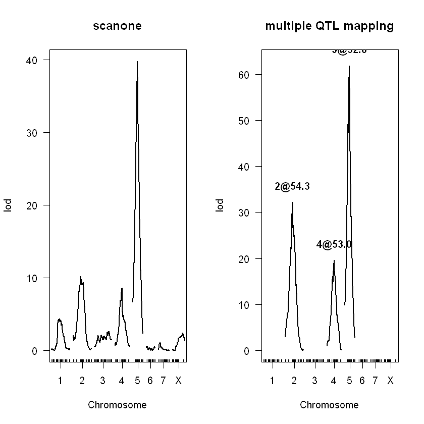

```r
par(mfrow=c(1,2))
plot(qtl_one_imp, main="scanone")
plotLodProfile(qtl_mqm_3_imp,showallchr=TRUE, main="multiple QTL mapping")
```

The last thing we need to cover is that beyond the peak location of the QTL, we might be interested in the uncertainty around that peak location. There are two options: LOD intervals, which constrain the location based on a drop in the LOD score from the peak (commonly used values are 1.5 LOD or 1-LOD and 2-LOD intervals):

```r
lodint(qtl_mqm_3_imp,qtl.index=1,drop=1.5,expandtomarkers=FALSE)
lodint(qtl_mqm_3_imp,qtl.index=2,drop=1.5,expandtomarkers=FALSE)
lodint(qtl_mqm_3_imp,qtl.index=3,drop=1.5,expandtomarkers=FALSE)
```

A scanone: 3 × 3

|  | chr <fct> | pos <dbl> | lod <dbl> |
| --- | --- | --- | --- |
| c5.loc31 | 5 | 31.00000 | 59.45645 |
| S002565_117003 | 5 | 32.80001 | 61.83090 |
| c5.loc34 | 5 | 34.00000 | 57.54561 |

A scanone: 3 × 3

|  | chr <fct> | pos <dbl> | lod <dbl> |
| --- | --- | --- | --- |
| c2.loc51 | 2 | 51.00000 | 29.68283 |
| S002151_1134795 | 2 | 54.30001 | 32.20114 |
| c2.loc56 | 2 | 56.00000 | 30.38959 |

A scanone: 3 × 3

|  | chr <fct> | pos <dbl> | lod <dbl> |
| --- | --- | --- | --- |
| c4.loc49 | 4 | 49 | 17.69420 |
| c4.loc53 | 4 | 53 | 19.61905 |
| c4.loc55 | 4 | 55 | 17.89671 |

Another option is to use Bayesian Credible intervals:

```r
bayesint(qtl_mqm_3_imp,qtl.index=1,prob=0.95,expandtomarkers=FALSE)
bayesint(qtl_mqm_3_imp,qtl.index=2,prob=0.95,expandtomarkers=FALSE)
bayesint(qtl_mqm_3_imp,qtl.index=3,prob=0.95,expandtomarkers=FALSE)
```

A scanone: 3 × 3

|  | chr <fct> | pos <dbl> | lod <dbl> |
| --- | --- | --- | --- |
| S000745_339612 | 5 | 31.80001 | 60.95344 |
| S002565_117003 | 5 | 32.80001 | 61.83090 |
| c5.loc33 | 5 | 33.00000 | 61.81447 |

A scanone: 3 × 3

|  | chr <fct> | pos <dbl> | lod <dbl> |
| --- | --- | --- | --- |
| c2.loc52 | 2 | 52.00000 | 31.60006 |
| S002151_1134795 | 2 | 54.30001 | 32.20114 |
| c2.loc55 | 2 | 55.00000 | 31.12922 |

A scanone: 3 × 3

|  | chr <fct> | pos <dbl> | lod <dbl> |
| --- | --- | --- | --- |
| c4.loc50 | 4 | 50 | 18.29951 |
| c4.loc53 | 4 | 53 | 19.61905 |
| c4.loc54 | 4 | 54 | 18.98200 |